# Methodology

What, if we do not assume independence of effects? Then we assume that the status of gene 1 has an effect on how much the statuses of genes 2, 3, …12 affect the outcome (growth rate). The the simplest model of interacting effects involves taking their product. And this results in lognormal distribution of growth rates.

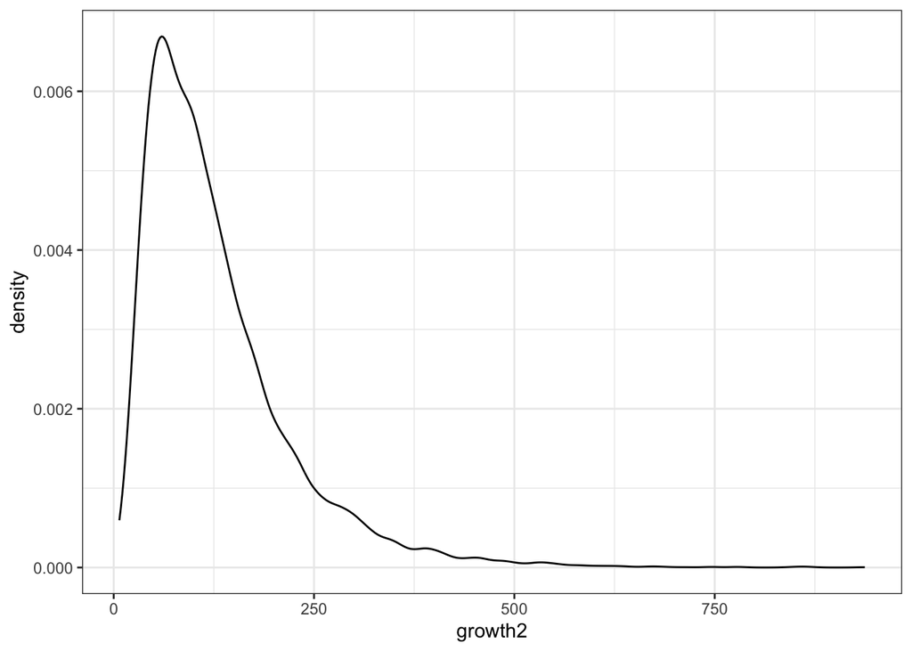

Interacting effects result in log-normal data

The thing with log-normally distributed data is that by taking the logarithm of such data (or by plotting them in log scale) we get normally distributed data.

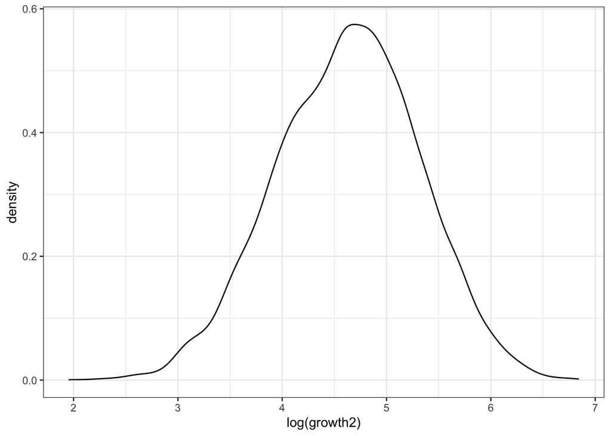

The best test of whether your data is lognormal is to take the logarithm of these data. In the log-scale these data should look normal.

If we think that our data comes from a process that generates approximately normal data (statistically speaking, we are talking about the population, not the sample), then we should model this by normal distribution. The full normal model is described by the function

$$f(x) = \frac {1}{\sigma \sqrt{2 \pi} } exp(-(\frac{(x - \mu)^2}{2 \sigma^2})$$

where x and $\mu$ are real numbers between -Inf and Inf, and $\sigma > 0$.

If we set mu to zero and sigma to one (this parametrization is called the *standard normal distribution*), we can calculate it like this:

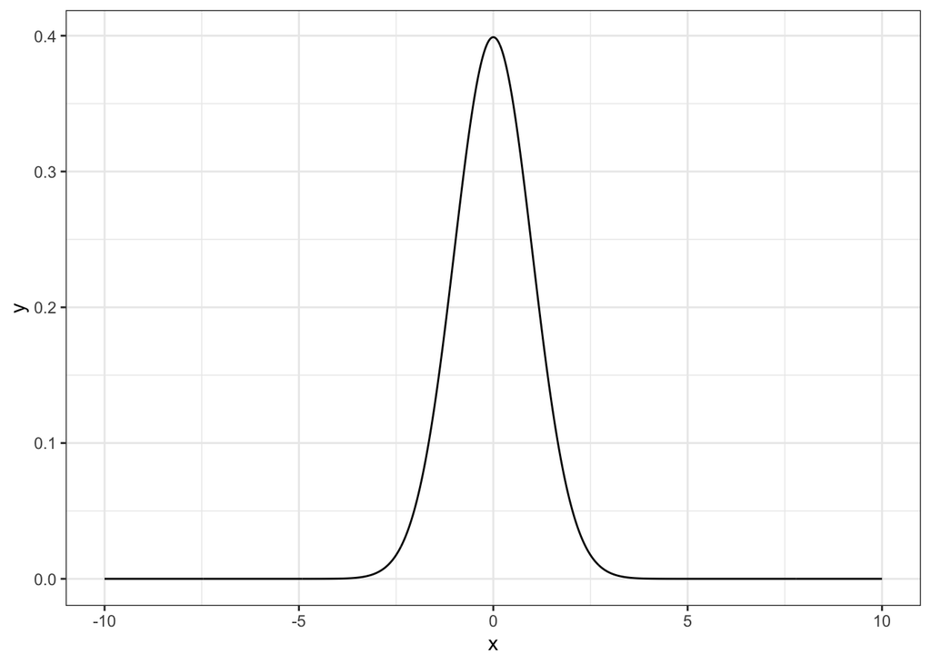

Standard normal distribution

```r
x <- seq(-10, 10, length.out = 1000)
mu <- 0
sigma <- 1
y <- (1/(sqrt(2*pi) * sigma)) * exp(-((x - mu)^2 /(2* sigma^2)))
ggplot(data=NULL, aes(x=x, y=y)) + geom_line() + theme_bw()
```

In R we have this function as dnorm()

```r
y <- dnorm(x=x, mean=0, sd=1)
ggplot(data=NULL, aes(x=x, y=y)) + geom_line() + theme_bw()
```

function rnorm() will draw random numbers from a normal distribution

```r
rnorm(3, mean=100, sd=10)
```

```
## [1] 106.13327  92.58037  99.39897
```

function qnorm() will show quantiles of normal distribution. For example, if p is a vector of probabilities, then

```r
qnorm(p=c(0.05, 0.95), mean=100, sd=10)
```

```
## [1]  83.55146 116.44854
```

tells us that if we draw random numbers from this distribution, then we can expect $5\%$ of these numbers to be smaller than 83.55 and $95\%$ to be smaller than 116.45. Thus 83.55 is the 5th percentile (quantile) and 116.45 is the 95th percentile (quantile) of this distribution. This also tells us that $90\%$ of the datapoints (probability density) will be in the range: 83.55 to 116.45.

function pnorm() gives the probability of obtaining a value $< q$ from a normal distribution.

```r
pnorm(q=83, mean=100, sd=10)
```

```
## [1] 0.04456546
```

So the probability of obtaining a sample value less than 83 is about $4\%$.

and the probability of obtaining a value between 85 and 100 is

```r
pnorm(q=100, mean=100, sd=10) - pnorm(q=85, mean=100, sd=10)
```

```
## [1] 0.4331928
```

In continuous distributions, it is important to understand that the probability density function or PDF defines a mapping from the y values (the possible values that the data can have) to a quantity called the density of each possible value. We can see this function in action when we use dnorm to compute, say, $dnorm(1, mean = 0, sd = 1)$: [1] 0.242 This quantity is not the probability of observing 1 in this distribution. As probability in a continuous distribution is the area under the curve, this area will always be zero at any point value. If we want to know the probability of obtaining values between an upper and lower bound b and a, i.e., P(a<Y<b) where these are two distinct values, we must use the cumulative distribution function or CDF: in R, for the normal distribution, this is the pnorm function. For example, the probability of observing a value between +2 and -2 in a normal distribution with mean 0 and standard deviation 1 is:

```r
pnorm(2, mean = 0, sd = 1) - pnorm(-2, mean = 0, sd = 1)
```

```
## [1] 0.9544997
```

Mathematically the lognormal model is described by this function:

$$f(x) = \frac{1}{x \beta \sqrt {2 \pi}} exp(- \frac{1}{2}(log(x/\alpha)/ \beta)^2)$$
kus $x > 0$
$$E(X) = \alpha \times exp(\beta^2/2)$$

Again, here we have a model with two parameters, but the EX and SD(X) no longer equal a model parameter.

$$SD(X) = \alpha ^2 \times exp(\beta^2) \times (exp(\beta^2) - 1)$$

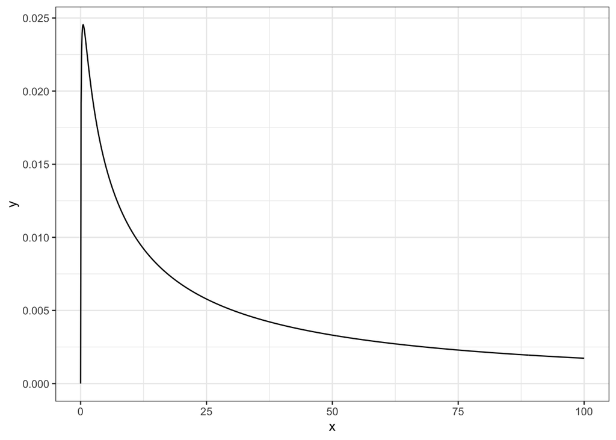

the log-normal model

```r
x <- seq(0, 100, length.out = 1000)
y <- dlnorm(x, meanlog = log(100), sdlog = log(10))
ggplot(data=NULL, aes(x=x, y=y)) + geom_line() + theme_bw()
```

Note that the R function `dlnorm()` takes its parameters in logarithmic form.

```r
qlnorm(p=c(0.05, 0.95), meanlog=log(100), sdlog=log(10))
```

```
## [1]    2.265408 4414.216471
```

```r
plnorm(q=c(2.265, 4414), meanlog=log(100), sdlog=log(10))
```

```
## [1] 0.04999194 0.94999780
```

> A probability distribution f(x) shows for each value of X, how likely it is to get this value, in relation to other values of X.

For continuous X we talk about probability density (functions), for discrete X we talk about probability mass (functions).

Not all probability distributions have defined expected value and/or SD. They may have other properties that make them usable models.

## 3.5. A philosophical aside

A probability distribution can arise in two ways. We just used the binomial distribution as a model for a coin tossing experiment. We assumed that we know how many times we plan toss the coin (N = 10) and, more importantly, that the coin is fair (prob = 0.5). Thus we fully understand the experiment and its results, albeit probabilistic, are also fully predictable. This is the deductive use of probability theory that, while making the implications of the coin tossing game excplicit, generates no new knowledge, which is not already present in the rules of the game. If we new the rules of the game, then general properties of the data that might happen are already implicitly present in those rules. We cannot say exactly, which data we will see, but we know exactly the probability of getting a head, from which we deduced the probability of getting k heads (or “k or more heads”, etc.) out of n tosses.

In classical philosophy there are two ways ways of understanding the world. One is knowldege (*episteme*), which is by definition true. Another is belief (*doxa*), which comes to us in degrees. Knowledge is the domain of mathematicians and philosophers, while belief is what everybody else has to survive on. Knowledge we can get deductively from axioms and beliefs we get inductively from the phyisical world. In the coin tossing simulation experiment, where we knew the data generating system, we calculated the probability distribution to get knowledge. But in the real world we never get to have knowledge in this sense, which means that we need to use probabilities differently.

This fundamentally different belief-generating usage of probability theory uses the results of N experiments (data) to guess the rules of the game. In particular, we would like to estimate the probability of getting heads. This means creating new knowledge which is not implicit in data. As we cannot create knowledge in this way, we have to make do with creating new beliefs. These new beliefs still come in the form of a probability distribution. To make this inductive leap we must go from the probability $P(data \vert rules)$ to $P(rules \vert data)$. For this we use the Bayes theorem, which we will explain in the next chapter.

Of course, we could ask for the probability that the coin is fair, but we already know this probability to be zero, as no coin is completely fair.

## 3.6. Probability theory and the Bayes theorem

> Words: proposition, conditional probability, prior probability, principle of total information, sample space

We define rationality narrowly as the best way of converting evidence into beliefs, and beliefs into decisions. Probability theory deals with the first part of this definition. Philosophically speaking, one could think of probability theory as a model of rational thinking, rather than the real thing, thus admitting that there might well be more to rationality than is captured by it, while stressing that probability theory does capture an important part of what it means to be rational.

How would you describe the thinking of a narrowly rational robot? What would we want to be the basic rules of reasoning or desiderata of such a robot, on which we could then formalize into a mathematical description of thinking under uncertainty. In other words, can we present a full list of norms of common sense, from which we can derive a rational thinking machine? These rules should be such that a rational person would not want to consciously violate any of them. Jaynes, E. T. (2003). Probability Theory: The Logic of Science. Cambridge University Press.

The robot reasons about unambiguous Aristotelian propositions, which have truth values (but we don’t need to actually know, whether a proposition is true or false, it suffices that it in principle has this truth-property). So it cannot help with much of ordinary human communication, to which unchanging truth values cannot be assigned.

The robot reasons by assigning degrees of plausibilities to propositions, based on evidence given to it. Each piece of new evidence leads to shifting of these plausibilities. Hence the 1st desideratum:

1. Degrees of plausibility are represented by real numbers. We represent a greater plausibility with a greater number.
2. Qualitative correspondence with common sense - if the robot gets information that supports hypothesis A, then the plausibility of A increases, and *vice versa*.
3. Consistency.

3.1. If a conclusion can be reasoned in many ways, then each must lead to the same result.

3.2. The principle of total information – all relevant information must be taken into account when shifting plausibilities. Also note that while causal physical influences propagate only forward in time, logical information works in both directions, so it does not matter when the evidence was collected in relation to the phenomenon it describes.

3.3. Equivalent states of knowledge are presented by equivalent plausibility numbers.

Surprisingly, these rules are enough to ensure a rational brain. Mathematical probability theory is fully consistent with these desiderata and requires no more than them.

Degrees of plausibilities are quantified by probabilities and probability distribution are gives a full description of uncertainty.

> The fundamental principle of all probabilistic inference: to judge the truth of proposition A, calculate the probability that A is true, conditional of all the evidence on hand: $P(A \vert E_1E_2…)$.

### 3.6.1. The Kolmogorov axioms

**Notation:**

$P(A)$ probability of A. A stands for proposition, event, hypothesis, parameter value, etc.

$\land$ - AND, $P(A \land B)$ means “probability that both A and B are true”

$\lor$ - OR, $P(A \lor B)$ means “probability that either A or B, or both A and B are true”

$\lnot$ - NOT, $P(\lnot A)$ means “probability of not A” or “probability that A is FALSE”.

$A \vert B$ - conditional, $P(A \vert B)$ means “probability of A given B” or “probability that A is true if we assume that B is true”

B does not have to be actually true, we just assume for the sake of argument that it is.

*Prior probability* $P(Hypothesis)$ is a purely logical term that incorporates all relevant evidence that is not present in data. The separation of evidence into “data” and “prior” is a matter of convenience of calculation, nothing more.

*Likelihood* $P(data \vert Hypothesis)$ models how likely is the sample data for each member of the sample space. If $\Omega =\{H_1,H_2\}$, then the likelihood space has 2 members as well: $P(data \vert H_1)$ is the probability of seeing sample data, if it happens that $H_1$ is true, and $P(data \vert H_2)$ is the probability of seeing sample data, if it happens that $H_2$ is true. If the likelihood ratio $LR = \frac{P(data \vert H_1)}{P(data \vert H_2)} = 1$, then the data is irrelevant. LR = 10 means that data supports $H_1$ ten times more than $H_2$.

> LR is also called *evidence*.

The fact that our sample data provides a lot more evidence for $H_1$ over $H_2$ does not in itself mean that we should think it more likely that $H_1$ is true than $H_2$, or any other logically possible hypothesis. Likelihoods do not sum to one over the sample space. Therefore, likelihood is not a true probability.

*Posterior probability* $P(Hypothesis \vert data~ \& ~prior)$ is the product of prior and likelihood over each member of the sample space, normalized over the posterior probability distribution so that probabilities sum to one. Posterior distribution is the output of Bayesian inference. This is the probability distribution that holds our beliefs about uncertainty concerning parameter values.

**Axioms:**

1. $P(A) \geq 0$
2. $P(\Omega) = 1$

   The probability of a sure thing is one, which means that the probabilities under a probability distribution sum to one.
3. $P(A \lor B) = P(A) + P(B)$, if A and B are independent.
4. $P(A~\vert~B) = \frac{P(A \land B)}{P(B)}$

   This is the definition of conditional probability. If you find it unintuitive, try this: in the urn there are 3 spheres and 3 cubes. Two of the spheres are blue and one is red. What is the probability that a random object drawn from the box is a red sphere? Solution: $P(sphere)=1/2$; $P(red ~\vert ~sphere)= 1/3$; $\begin{array}{lcl} P(sphere \land red)=P(sphere)P(red ~\vert sphere)\\ = 1/2 \times 1/3 = 1/6. \end{array}$

The definition for conditional probability arises naturally from set theory: The number of elements in sample space S is n(S), and S contains two subspaces A and B, which have an overlap (intersection) $A \land B$. Calculating $P(A \vert B)$ is the same as calculating the number of elements contained in the intersection of A and B, relative to the number of elements contained in the whole subspace B: $P(A \vert B) = \frac{n(A \cap B)}{n(B)}$. By dividing both numerator and denominator with n(S) we convert absolute numbers into fractions, a.k.a. probabilities:

$$P(A \vert B) = \frac{n(A \cap B)/n(S)}{n(B)/n(S)} = \frac{P(A \cap B)}{P(B)}$$

### 3.6.2. Some derivations

5. $0 \leq P(A) \leq 1$ - probabilities are bounded by 0 and 1.
6. $P(\lnot A) = 1 - P(A)$
7. Monotonicity: if B is a subset of A ($B \subset A$), then $P(B) \leq P(A)$. If B can be deduced from A: $[A \lor (B \land \lnot A) \Leftrightarrow B]$, then $P(B) \leq P(A)$.
8. $P(A \land B) \le P(A)$; $P(A) \leq P(A \lor B)$
9. If B can be deduced from A and $P(A) > 0$, then $P(B~ \vert ~A) = 1$ and $P(\lnot B~ \vert A) = 0$.

   If evidence *e* can be duduced from hypothesis *H* (*H* predicts *e*) and if $P(H) > 0$ and $P(e) < 1$, then $P(H~ \lvert~ e) > P(H)$, or *e* increases the probability of *H*.
10. Logically equivalent propositions/hypotheses have the same probability: if $A \Leftrightarrow B$, then $P(A) = P(B)$
11. Def: A and B are independent (not correlated) if and only if $P(A~ \vert B) = P(A)$
12. If A and B are independent, then
    $$P(A\land B) = P(A)P(B)$$
13. If A and B are not independent, then
    $$P(A \lor B) = P(A) + P(B) - P(A \land B)$$
    and for 3 events:
    $$\begin{array}{lcl} P(A \lor B \lor C) = P(A) + P(B) + P(C) - \\P(A \land B) - P(B \land C) - P(A \land C) + \\P(A \land B \land C) \end{array}$$

### 3.6.3. The Bayes theorem

We can derive the Bayes theorem straight from the definition of conditional probability (4.)

$$P(A\vert B) = \frac{P(A \land B)}{P(B)}$$
,

and equivalently
$$P(B\vert A) = \frac{P(B \land A)}{P(A)}$$
.

As
$$P(A \land B) = P(B \land A)$$

$$P(A\vert B)P(B) = P(B\vert A)P(A)$$
and

$$P(A\vert B) =\frac{P(A)P(B\vert A)}{P(B)}$$
This is the Bayes Theorem. Now, lets substitute A with Hypothesis H and B with data d.

$$P(H \vert d) =\frac{P(H)P(d\vert H)}{P(d)}$$
Here $P(H~\vert~ d)$ is the posterior, $P(H)$ is the prior probability of the hypothesis, $P(d~\vert~H)$ is the likelihood, or the probability of data given the hypothesis, and $P(d)$ is the total probability of the data, summed over all the hypotheses in the sample space. P(d) is the normalization member, which guarantees that the posterior probabilities sum to one over the sample space.

**The single most important thing to remember is that posterior is proportional to the product of prior and likelihood.**

What does $P(d)$ really mean? If $\Omega = \{H, \lnot H \}$, then

$$P(d) = P(d \land H) + P(d \land \lnot H) = P(H)P(d\vert H) + P(\lnot H)P(d\vert \lnot H)$$

where the final step comes from the definition of conditional probability.

**Example** (with real US data from the spring of 2020): We have an antibody test for COVID-19. If 1000 covid-19 positive patients are tested, on average 840 of them get a true-positive result (sensitivity of the test is 84%). If 1000 non-infected people are tested, 5 get a false-positive result (specificity of the test is 1 - 0.005 = 0.995, or 99.5%). We think that about 1% of the population has been exposed to the virus. Now, if a random person gets a positive result, what is the probability that this person is infected?

```r
Pr_H1 = 0.01
Pr_H2 = 1 - Pr_H1
L_H1 = 0.84
L_H2 = 0.005
(Pr_infected = (Pr_H1 * L_H1)/(Pr_H1 * L_H1 + Pr_H2 * L_H2))
```

```
## [1] 0.6292135
```

There is a more intuitive solution. Imagine 1000 random persons, 10 of whom are infected and 990 are not. Now from the infected 10 x 0.84 = 8.4 test positive and from the uninfected 990 x 0.005 = 5 test positive. The probability of being infected, if getting a positive test result, is then 8.4/(8.4+5) = 0.63.

NYT 24.08.2020:

> Getting an antibody test to see if you had Covid-19 months ago is pointless. Many tests are inaccurate, some look for the wrong antibodies and even the right antibodies fade away, said the Infectious Diseases Society of America, which issued the new guidelines. Antibody testing generally should be used only for population surveys, not for diagnosing illness in individuals, the panel said. Even for that purpose, only tests that are correctly positive more than 96 percent of time and correctly negative at least 99.5 percent of the time should be used, according to the guidelines. Very few of the dozens of tests that the panel looked at met those standards. None can be done at home or immediately in doctors offices, and the best are assays known as Elisa or chemiluminescence immunoassay. With two exceptions, antibody tests should not be used to diagnose individual infections, the society said. When a patient has all of the symptoms of Covid-19, including X-ray evidence of pneumonia, but still comes up negative on repeated diagnostic PCR tests for the virus, an antibody test may be useful. The tests can also be used for diagnosis when a doctor suspects a child has multisystem inflammatory syndrome, a rare but serious complication of Covid-19 in children. Because it is not known how long after the initial infection this inflammation begins, doctors should do both a PCR test and an antibody test, the guidelines said.

What if we want to estimate the true value of a continuous parameter (for example the probability that a patient dies of COVID_19, or the mean length of hospitalization with COVID-19)? In such cases the hypothesis space consists of infinite number of elements (real numbers from 0 to 1, and integers from 0 to Inf, respectively). This means that we must specify an infinite number of likelihoods and an infinite number of prior probabilities, before we can run the calculation! Luckily we can do this using continuous functions, which by definition specify infinite number of points. Then the posterior will be a continuous function as well.

More generally, for a sample space with n members (n mutually exclusive and exhaustive hypotheses) $\Omega = \{H_1, H_2, ...H_n \}$ and

$$P(d) = P(H_1)P(d\vert H_1) + P(H_2)P(d\vert H_2) + ... + P(H_n)P(d\vert H_n)$$

This is the formula for total, a.k.a. marginal, probability.

So the Bayes theorem becomes

$$P(H_1\vert d) =\frac{P(H_1)P(d\vert H_1)}{P(H_1)P(d\vert H_1) + P(H_2)P(d \vert H_2) + ... + P(H_n)P(d \vert H_n)}$$

Now we have a formula that allows us, in logically the best way, to combine evidence that is present in sample data (as modeled in the likelihood) with data-independent beliefs (as modeled in the prior), and end up with a posterior probability of hypothesis, given data and prior. In other words, we can use the Bayes theorem to combine disparate strands of information into a single posterior that (usually) comes in the form of probability distribution. There is no magic involved, just basic probability theory. The Bayes theorem is not a truth machine – it just combines information that we put into it. If the information in the prior or in the likelihood is grossly wrong, there is no guarantee that even in the long run the posterior converges on truth (although under most realistic scenarios it does just that). Importantly, Bayes theorem works iteratively and there is no lower limit of data that you can put into it: N=1 is fine.. Also, it is easy to incorporate new data, as you can simply redefine your posterior from the previous iteration as the new prior, add new data as likelihood, and calculate the new posterior, which before long will become a prior. Thus Bayesian inference recapitulates the piecemeal nature of scientific inference. Importantly, unlike with frequentist statistics, there are no stopping rules, meaning that you can safely calculate the posterior after receiving each new datum. In addition, as Bayesians calculate the probabilities of hypotheses/parameter values directly, the have no need for the sampling distribution of data, which lets them off the hook with the random sample. Bayesians look at the exact data, not some imaginary random sample from an infinite statistical population. As frequentist statistics needs its samples to be independent and identically distributed random variables (*iid*, also see point 11.), for Bayesian analysis the data need less restrictively to be merely exchangeable, meaning that the order by which individual datums are put through the analysis should not have any effect on the results.

Frequentist statistics does not work like this. There you need to have some minimum N for the algorithms to work as advertised.

In frequentist statistics you need stopping rules (predetermined sample size), so you would not simply call a “significant effect” as soon as the randomly fluctuating p value first drops below the significance level. In Bayesian statistics there is no significance level and no dichotomization of continuous evidence, so stopping rules would be meaningless.

> Bayesian inference comes straight from probability theory, while frequentist inference is a collection of ad hoc procedures, which require more stringent conditions to work properly.

# 4. The basics of Bayesian inference

In frequentist statistics the main workflow is something like this:

1. Decide on the stopping rules and statistical tests that will be used, write a pre-registered analysis protocol.
2. Do a power analysis to determine optimal sample size N for finding significant effects
3. Collect the sample of size N (no more, no less). There can be no peeking at data, unless pre-specified in step 1, until the full sample is collected. The sample needs to be analysed together. Ideally the experiment is randomized and blinded, so the researcher does not know, which is the experimental group and which is the control group.
4. Run the pre-specified statistical test on pre-specified variables, which have been normalized and transformed according to the pre-specified protocol.
5. Check the test assumptions (normality, linearity, constant variance, etc.) by running additional tests on your data and on the fitted model.
6. If these assumptions are satisfied, interpret the p value as significant or not.

In general, a frequentist analysis should be completely pre-registered to avoid multiple testing problems that arise largely (but not solely) because of dichotomizing continuous evidence by the statistical significance criterion. This avoidance of “researcher degrees of freedom”, which can destroy the long-run quality control properties of frequentist tests, makes the analysis very rigid, and often equally frigid, or incapable of reacting to different-than-expected results. It is a serious mistake to suppose that frequentist requirements to statistical inference, which come from the need to fix the long-run frequency of type 1 errors, reflect how real scientists do real scientific inference.

While multiple testing, narrowly understood, is not a problem for the Bayesian, false alarms are. The currently favored Bayesian mitigation of false alarms is multilevel modeling.

In Bayesian statistics we do not care about stopping rules and instead of a power analysis we might simulate realistic-looking data and try to analyse these, to see whether the models and algorithms to fit them work well enough for these kind of data. This will also double as a power analysis as one can find an optimal sample size that gives sensible estimates. Also, we do not pre-specify, which models we will use on our data, as we will build several bespoke models depending on the data that we eventually get, so we can compare the models and their fits, and try to learn from them as a group. Instead of formally checking model assumptions, we rather generate simulated data from the fitted models and compare with actual data, to see, which aspects of our data are well represented in the model structure, and which ones are not. This approach is a major benefit of the Bayesian approach. As a whole, Bayesian modeling is much more flexible, both in terms of model structures and in how we work with the models, in that it tries to mirror the scientific process, where we gradually learn from data, and from our mistakes, to build better experiments and better ways of analysing their results.

A simplified Bayesian procedure:

1. model data as likelihood, by using an appropriate probability distribution that reflects the data generating mechanism.
2. model additional information as prior, by using a probability distribution that best allows to describe your prior beliefs.
3. use a Bayesian procedure to get a posterior. These days, instead of trying to calculate from the Bayes theorem directly, which can be overwhelming computationally, various MCMC approximations are used.
4. compare the model fits, and the posteriors that we got from different models
5. As needed, modify your models to achieve better fit and more realistic model-generated data. Then repeat the cycle, until you are satisfied.
6. interpret the posteriors in scientific context, make counterfactual predictions from the fitted model.

It should be noted that at the end of the day both Bayesian and frequentist statisticians want the same thing. They want to use the fits of statistical models in formulating scientific conclusions. The numerical outputs of statistical models themselves are not it. They have to be interpreted in non-mathematical and out-of-the-model contexts. However, by artifice and by tradition the two great traditions of statistics go about their business in quite different ways.

In frequentist statistics it is usually the raw effect sizes and the p values that get interpreted. In Bayesian statistics, they are the shrunk effect sizes (we will learn soon, what this means) and the assorted credible intervals. In frequentist inference usually a single model is interpreted per effect, while in Bayesian inference often several models are interpreted together. In frequentist inference the statistically non-significant effects are often not interpreted at all (this is not what frequentist theory proposes, but rather an unfortunate historical accident), in Bayesian inference all effects are interpreted together (remember that the *law of total information* is a law of logic; you do not want to go around, breaking these!).

## 4.1. Fitting the Binomial data model

Mortality of a disease is 50% and we have 3 patients. How many of them are likely to die? We have 2 pieces of data (mortality rate p = 0.5 and N = 3) and a 4-member sample space (0 dead, 1 dead, 2 dead, and 3 dead). We start by enumerating all logically possible scenarios (d - dead, a - alive)

d d d

d a d

d d a

a d a

a a d

a a a

a d d

d a a

Kui P(dead) = 0.5, then by simple counting we get that:

- 0 dead - 1,
- 1 dead - 3,
- 2 dead - 3,
- 3 dead - 1

Thus we have 1 + 3 + 3 + 1 = 8 possible futures that divide between the 4 hypotheses. This means that for each member of the parameter space we know the probability of its realization (P(1 death) = 3/8, etc.). It is this knowledge we now turn into a likelihood function.

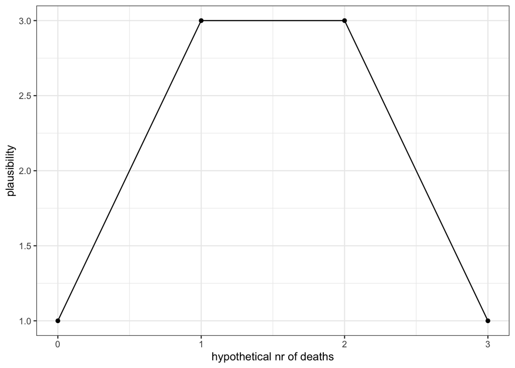

```r
# Parameter space: all possible futures
x <- seq(from = 0, to = 3)

# Likelihoods for each x value,
# or P(deaths I x)
y <- c(1, 3, 3, 1)

ggplot(data=NULL, aes(x, y))+

  geom_point()+
  geom_line()+

  xlab("hypothetical nr of deaths")+

  ylab("plausibility")+
  theme_bw()
```

One death and two deaths are equilikely and one death is three times as likely as no deaths (or three deaths). Likelihood simply tells for each number of deaths, how likely is this outcome, given the mortality figure that we state.

Now we demonstrate the same using the binomial distribution model. The only difference is that now we get on the y-axis normalized probabilities.

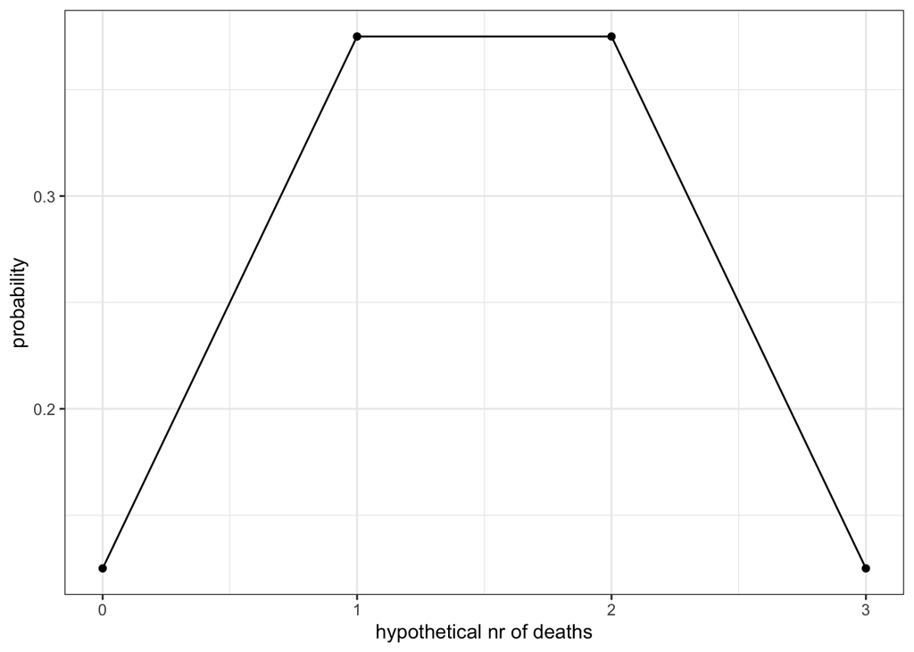

```r
y <- dbinom(x, 3, 0.5)

ggplot(data=NULL, aes(x, y)) +

  geom_point()+
  geom_line()+

  xlab("hypothetical nr of deaths")+

  ylab("probability")+
  theme_bw()
```

How many dead when we have 9 patients and mortality rate is 67 percent?

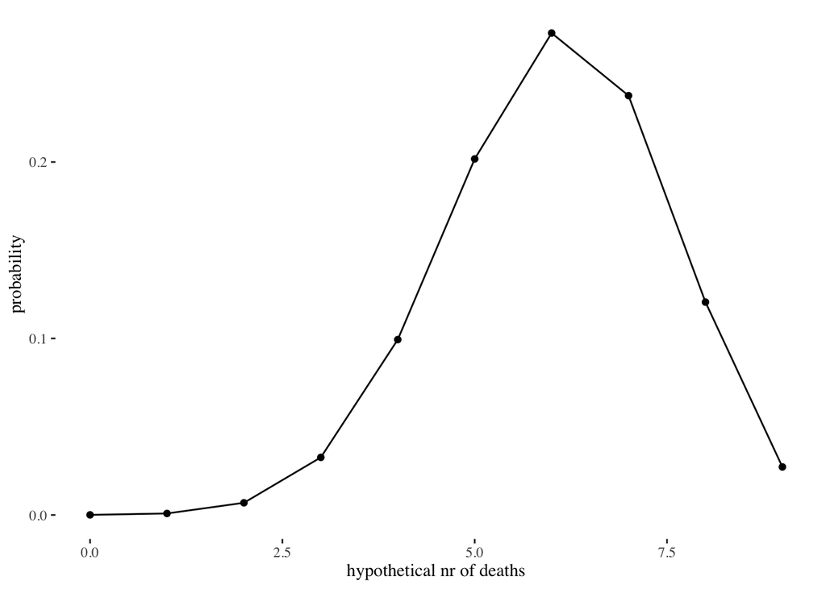

```r
x <- seq(from = 0, to = 9)
y <- dbinom(x, 9, 0.67)

ggplot(data=NULL, aes(x, y)) +

  geom_point()+

  geom_line()+

  xlab("hypothetical nr of deaths")+

  ylab("probability")+

  ggthemes::theme_tufte()
```

Next we add to the likelihood a flat prior and use the Bayes theorem.

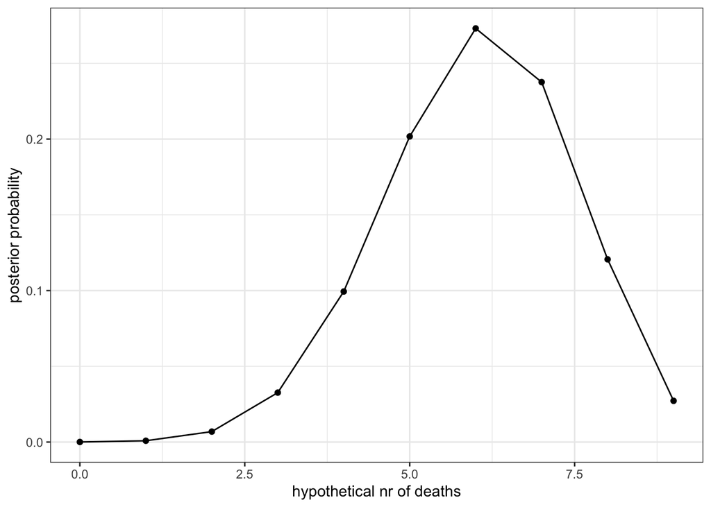

```r
x <- seq(from = 0 , to = 9) #parameter space: nr of deaths
prior <- rep(1 , 10) # flat prior

# Compute likelihood at each value in grid
likelihood <- dbinom(x, size = 9, prob = 0.67)

# Compute product of likelihood and prior
unstd.posterior <- likelihood * prior

# Normalize the posterior, so that it sums to 1
posterior <- unstd.posterior / sum(unstd.posterior)

ggplot(data = NULL, aes(x, posterior)) +

  geom_point() +
  geom_line() +

  xlab("hypothetical nr of deaths") +

  ylab("posterior probability")+
  theme_bw()
```

Now its time for a shift of perspective. We want to estimate the true mortality rate.

- data: 6 dead out of 9 patients.
- parameter to estimate: the mortality rate (p).
- sample space: real numbers between 0 and 1.

We can still use binomial likelihood. dbinom() has 3 arguments, nr of events, nr of tries and probability of events. Again, we have two of them as data and one as the parameter whose value we want to estimate. We use the flat prior again. As there are Inf number of members in $\Omega$, we cheat a little and calculate for the grid of 20 evenly spaced parameter values.

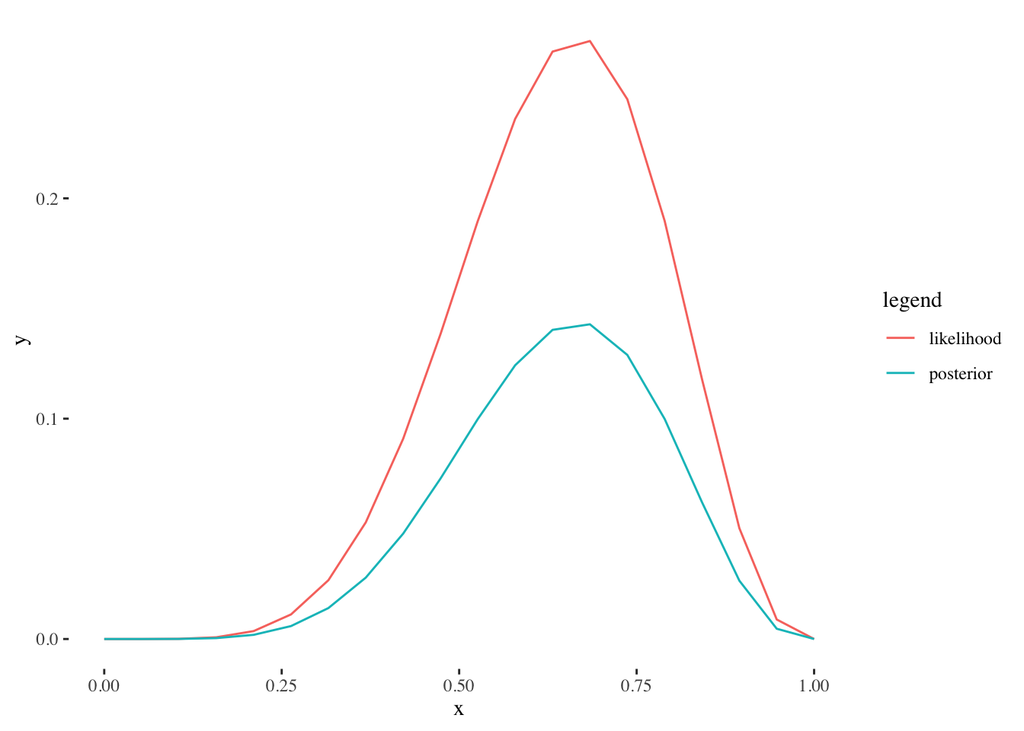

```r
# grid: mortality at 20 evenly spaced probabilities from 0 to 1
x <- seq(from = 0 , to = 1, length.out = 20)

# prior
prior <- rep(1 , 20)

# likelihood at each value in grid
likelihood <- dbinom(6, size = 9 , prob = x)

posterior <- likelihood * prior / sum(likelihood * prior)

a <- tibble(x=rep(x=x, 2),

            y= c(likelihood, posterior),

            legend= rep(c("likelihood", "posterior"), each=20))

ggplot(data=a) +

  geom_line(aes(x, y, color=legend))+

  ggthemes::theme_tufte()
```

Our posterior sums to 1, but thanks to flat prior its shape is the same as the likelihood.

Lets do this datapoint-by datapoint, so that n = 1.

First datapoint is that the 1st patient died.

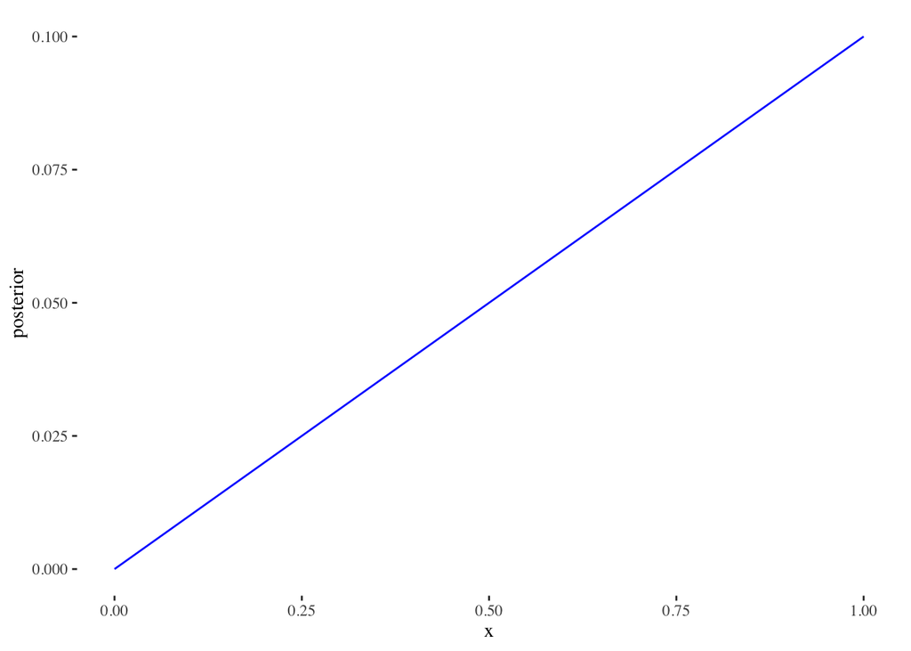

```r
likelihood <- dbinom(1, size = 1, prob = x)
posterior <- likelihood * prior / sum(likelihood * prior)
ggplot(data=NULL)+

  geom_line(aes(x, posterior), color= "blue")+

  ggthemes::theme_tufte()
```

Zero mortality is now logically impossible and 100 percent mortality is the hypothesis best supported by the data.

Second datapoint is that the 2nd patient died. Our previous posterior is now the prior.

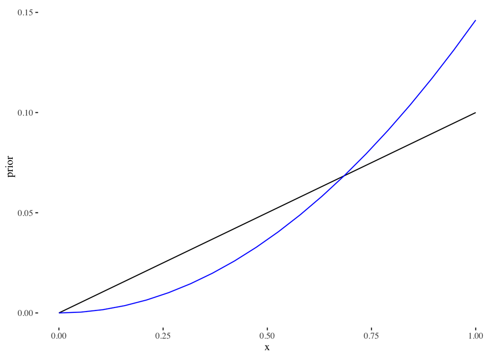

```r
prior <- posterior
likelihood <- dbinom(1 , size = 1, prob = x)
posterior1 <- likelihood * prior / sum(likelihood * prior)
ggplot(data=NULL)+

  geom_line(aes(x, prior))+

  geom_line(aes(x, posterior1), color="blue")+

  ggthemes::theme_tufte()
```

The posterior is no longer a straight line. 100 percent mortality is still the most likely mortality estimate.

Third datapoint is that the 3d patient survived.

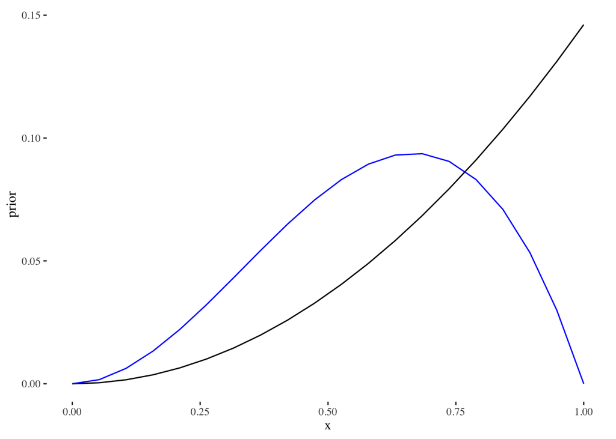

```r
prior <- posterior1
likelihood <- dbinom(0, size = 1, prob = x)
posterior2 <- likelihood * prior / sum(likelihood * prior)

ggplot(data=NULL)+

  geom_line(aes(x, prior))+

  geom_line(aes(x, posterior2), color="blue")+

  ggthemes::theme_tufte()
```

## 4.2. Normal data model

Richard McElreath:

> There are an infinite number of possible Gaussian distributions. Some have small means. Others have large means. Some are wide, with a large $\sigma$. Others are narrow. We want our Bayesian machine to consider every possible distribution, each defined by a combination of $\mu$ and $\sigma$, and rank them by posterior plausibility. Posterior plausibility provides a measure of the logical compatibility of each possible distribution with the data and model. … The parameters to be estimated are both $\mu$ and $\sigma$, so we need a prior $Pr(\mu , \sigma)$, the joint prior probability for all parameters. In most cases, priors are specified independently for each parameter, which amounts to assuming $Pr(\mu, \sigma) = Pr(\mu) Pr(\sigma)$.

How does one make a US president? Lets start by generating some heights of presidential candidates. We assume that human growth is a deterministic process that depends on a complex mix of many genetic and environmental factors. But we really do not understand this process well enough to directly use it to generate prospective heights of future presidents. We think that human height is approximately normally distributed (conditional on sex, age, etc.), so we could model presidential heights as a normal distribution where each possible height is given a probability of occurring. Now, we could generate new heights from this stochastic model proportionally to these probabilities. But before we do this, we have to fix the shape of the normal distribution so that we know the relevant probabilities. This can be done by fixing the values of two parameters of the normal distribution, $\mu$ and $\sigma$. Luckily we have data on the heights of the last 12 presidents:

```r
heights <- tibble(value = c(183, 192, 182, 183, 177, 185, 188, 188, 182, 185, 188, 182))
```

As the parameter $\mu$ is identical to the expected value, i.e. the mean of the normal distribution and $\sigma$ to standard deviation (SD), we can simply calculate those and then use these numbers to generate new heights.

Data mean is:

```r
(Mean <- mean(heights$value))
```

```
## [1] 184.5833
```

and SD is:

```r
(SD <- sd(heights$value))
```

```
## [1] 3.964807
```

Predict 4000 new heights and calculate standard deviation:

```r
set.seed(1)
rnorm(4000, Mean, SD) %>% sd()
```

```
## [1] 4.10711
```

This procedure is not ideal, though, as it does not take into account the fact that our estimates of $\mu$ and $\sigma$, calculated from limited data, are not precisely true for the full population of US presidents, including the future ones. So on top of the randomness in predicting new presidents that comes from our imperfect knowledge of the mechanisms that generate human heights we must model the uncertainty that comes from imperfect data. How can we do this? When modelling this 2nd order epistemic uncertainty we will to end up not with point estimates of $\mu$ and $\sigma$, but probability distributions for $\mu$ and $\sigma$ values. This way we are not predicting new heights from a single fixed normal distribution, but rather from many different distributions, where each is parametrized by a plausible combination of $\mu$ and $\sigma$ values (each of these combinations is supported by the data and by our prior knowledge of plausible presidential heights).

```r
pres_m <- brm(data = heights, formula = value~1, file="models/pres_m")
pres_posterior_sample <- posterior_samples(pres_m)
set.seed(1)
rnorm(4000, pres_posterior_sample$b_Intercept, pres_posterior_sample$sigma) %>% sd()
```

```
## [1] 4.546833
```

Now the standard deviation of predicted presidents heights is slightly larger (by 0.44 cm), reflecting the extra uncertainty. Note that the model pools both kinds of uncertainties so that we cannot re-separate them in later analysis.

Next we fit this model the old-fashioned way, using the Bayes theorem with grid approximation.

   This is Bayesian method in a nutshell: at each parameter value (x) we multiply the likelihood (y_lik) with the prior (y_pr), thus combining our prior knowledge with the data and the data model. Knowledge (prior and data) in – knowledge (posterior) out.

**Some preliminary points:**

Now, lets go on. Next item in the menu is the grid method for posterior in 2D. Instead of multiplying likelihoods, we will add log-likelihoods (which is mathematically the same thing).

The model is:

$$height_i \sim normal(\mu, \sigma)$$

$$\mu \sim normal(175.4, 5)$$

$$\sigma \sim normal(5.2, 1)$$

Where the 1. line is the likelihood, containing two parameters, and the next 2 lines are priors for each parameter.

i is index for heights, which means that the model assumes that each individual height comes from the same normal distribution.

### prior predictive simulation

Here we calculate the posterior solely on the prior. As we add no likelihood, the data has no influence on the posterior – only the prior does.

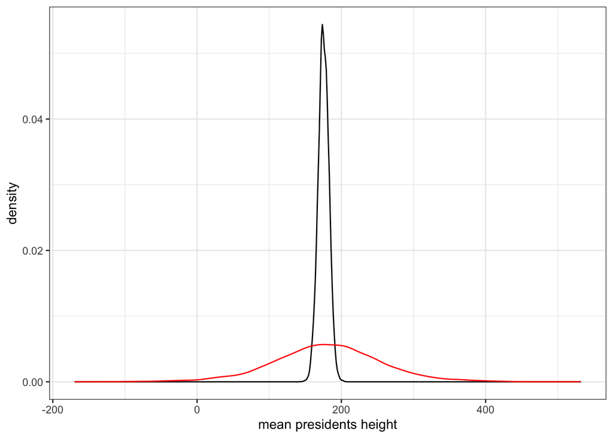

A prior predictive check.

```r
mu_prior1 <- rnorm(10000, 175.4, 5)
mu_prior2 <- rnorm(10000, 180, 50)

sigma_prior1 <- rnorm(10000, 5.2, 1)
sigma_prior2 <- runif(10000, 0, 100)

y1 <- rnorm(10000, mu_prior1, sigma_prior1)
y2 <- rnorm(10000, mu_prior2, sigma_prior2)

ggplot(data=NULL, aes(x=y1)) +
  geom_density()+

  geom_density(aes(x=y2), color="red")+

  xlab("mean presidents height")+ theme_bw()
```

We use two different prior combinations: one is informative (the black line in the figure) and another one is weakly informative (red), meaning that it carries no useful biological information, but nevertheless gives a lot more weight to postive values and values < 4 meters (thats right - this prior assumes that 4-meter mean height is possible). Currently, weak priors are all the rage, because they make model fitting by MCMC methods easier, while requiring minimal scientific input. Lets hope that this situation is about to change in favour of strong scientifically informed priors!

### Calculating the 2D posterior

The posterior is a joint distribution over all parameters in the model. If we have 2 parameters, then we have a 2D posterior. If we have 200 parameters, then we have 200D posterior. We can always collapse the posterior to a desired 1D view for inspection (see below).

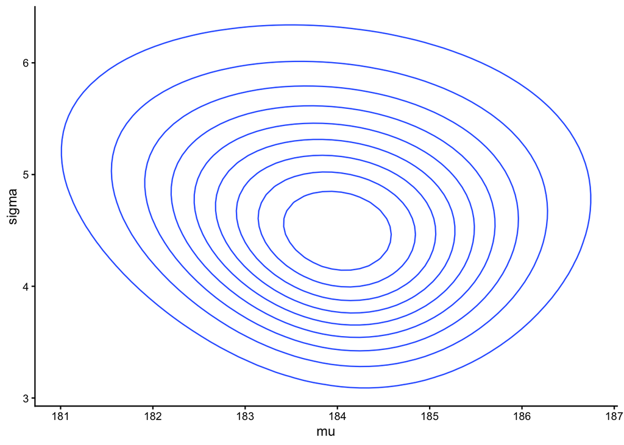

```r
# d_grid contains all possible combinations (10 000) of mu and sigma values.
n <- 100
d_grid <- crossing(mu = seq(from = 180, to = 190, length.out = n),

#crossing() expands the table to cover all possible combinations.

                   sigma = seq(from = 1, to = 8, length.out = n))

#grid_function generates a density value from a normal function,
#whose x is a vector of presidents height and mu and sigma are plucked from d_grid.
#sum() in the log-scale is prod() in the linear scale. In each row of d_grid
#we multiply likelihoods (actually, sum log-likelihoods) for each data point, using
#different combinations of mu and sigma to model the normal distribution.

grid_function <- function(mu, sigma) {

  dnorm(heights$value, mean = mu, sd = sigma, log = TRUE) %>% sum()

}


d_grid <- d_grid %>%

  mutate(log_likelihood = map2_dbl(mu, sigma, grid_function),

# map2_dbl() takes each mu and sigma pair in d_grid (row-wise) and puts it into the grid_function

         prior_mu    = dnorm(mu, mean = 175.4, sd  = 5, log = TRUE),

#for each value of mu (one in each row) we calculate normal density from prior distr.

         prior_sigma = dnorm(sigma, mean = 5.2, sd = 1, log = TRUE),

#for each value of sigma we calculate normal density from prior distr. for sigma

         product = log_likelihood + prior_mu + prior_sigma,

#sum() in the log-scale is product in the linear scale.

         probability = exp(product - max(product)))
#product - max(product) mirrors into negative scale, which after exp() becomes probability scale.
#probability vector contains the posterior probabilities across mu and sigma.

d_grid %>% ggplot(aes(x = mu, y = sigma, z = probability)) +

  geom_contour() + theme_classic()
```

This 2D posterior is drawn as a 3D surface, where the third dimension is posterior probability. In the center of the contour is the peak of the posterior distribution. This is, by the way, a bivariate normal distribution.

geom_contour() visualizes 3D surfaces in 2D. To specify a valid surface, the data must contain x, y, and z coordinates, and each unique combination of x and y can appear once.

### Sampling from the posterior – 1D posteriors for mu and sigma.

I am sampling randomly while weighting on probability, so that mu values with higher posterior probability are more likely to end up in the sample. From such random samples of mu and sigma (the posterior samples) we can plot the posteriors:

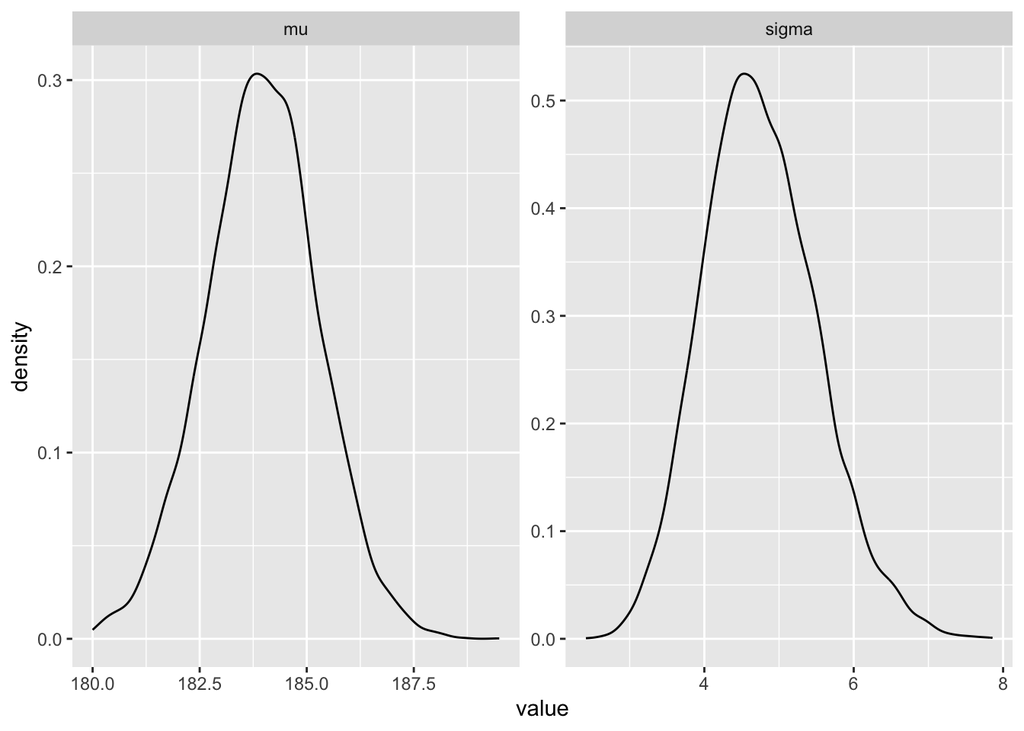

```r
d_grid_samples <-
  d_grid %>%
  sample_n(size = 1e4, replace = TRUE, weight = probability)

d_grid_samples %>%

  pivot_longer(mu:sigma) %>%

  ggplot(aes(x = value)) +

  geom_density() +

  facet_wrap(~name, scales = "free")
```

### summarising the posterior (95% HDI)

```r
posterior_summary(d_grid_samples[,1:2])
```

```
##         Estimate Est.Error      Q2.5      Q97.5
## mu    183.951485 1.3195671 181.31313 186.565657
## sigma   4.755323 0.7611191   3.40404   6.373737
```

### Triplot for mu

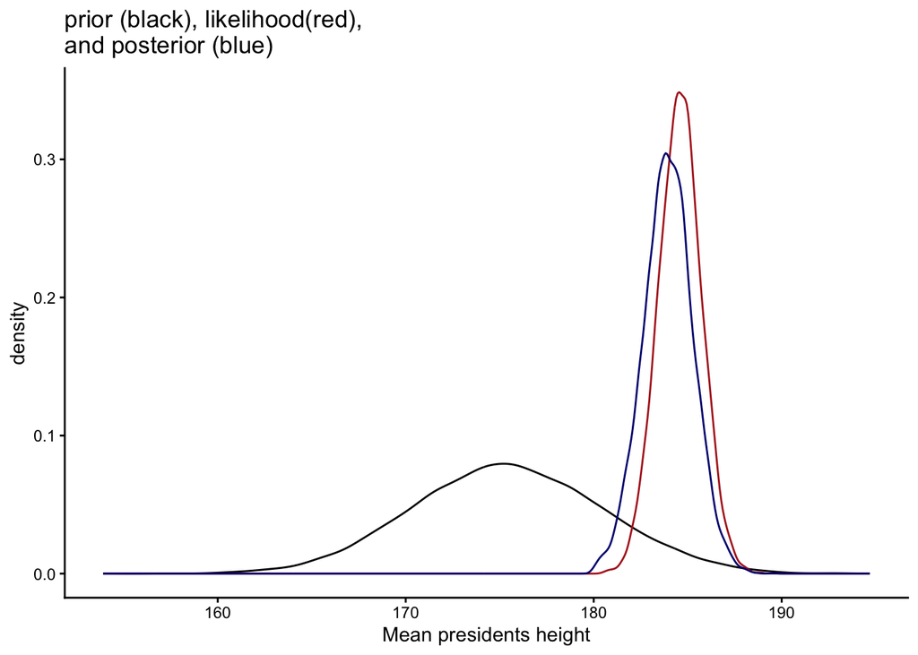

```r
prior_mu <-  rnorm(10000, mean = 175.4, sd  = 5)
lik_mu <- rnorm(10000, mean= mean(heights$value),
                sd = sd(heights$value)/sqrt( nrow(heights) ) )
post_mu <- d_grid_samples$mu

ggplot(data=NULL, aes(prior_mu)) +

  geom_density() +

  geom_density(aes(lik_mu), color="firebrick") +

  geom_density(aes(post_mu), color="navyblue") +

  xlab("Mean presidents height")+

  ggtitle("prior (black), likelihood(red), \nand posterior (blue)")+

  theme_classic()
```

### Some things to notice

1. As the priors are true probabilities that sum to one, and the likelihoods are not, we can run our models on either priors and data, or on priors alone, but never on data alone. Running a model on priors alone can be a good idea, if you want to know, how much your data influences the model fit. When you have little data and strong priors, this is the thing to do.
2. Each fitted model with k parameters gives you a k-dimensional posterior (this is slightly more complicated with multi-level models), which we flatten into k side-by-side variables in the posterior samples table. This means that we have to treat each row of this table as a single unit, when we use them in further calculations. In each row there is one plausible combination of k parameter values – if you mix the values between rows, this might no longer hold.

# 5 Basic linear regression

Lets start by thinking once more about modeling a normally distributed continuous variable, y, with the normal model:

$$y \sim normal(\mu, \sigma)$$

We will get the mean y ($mean = \mu$) and data level sd ($SD = \sigma$) from this model. But what if we want to model the mean y and/or the sd stratified according to different levels of another variable, x?

Suppose that we have measured on each object of measurement its height and we also know its sex. We code the male sex with 0 and female sex with 1, so the sex is now technically a continuous variable, for modeling purposes. We want to model the mean height for sex = 0 and for sex = 1 subjects. The easiest way to do this would be to partition the data by sex and run 2 separate models.
$$h_{sex = 0} \sim normal(\mu, \sigma)$$

$$h_{sex = 1} \sim normal(\mu, \sigma)$$
We will get separate estimates from separate models, which know nothing of each other, and from these, we can get effect sizes with full posteriors.

posterior_mu_model1 - posterior_mu_model2 gives the posterior for the effect size, i.e. by how much on average are males taller than females.

This is wasteful, however, because we could use the information on females heights on males heights, and *vice versa*. The model, by which we do this, is called *linear regression*. We regress y on x. The regression model differs from the simple $y \sim normal()$ model in that as the simple model estimates the unconditional (a.k.a. marginal) probability of P(Y), the regression model estimates a conditional probability $P(Y\vert x_i)$, where $x_i$ stands for some fixed value(s) of one or more predictor variables. We estimate the mean value of Y given pre-specified exact values of X.

> In principle, we should strive for big models that use all our data. However, for practical reasons, we can also divide the data and run separate models. Statistics is a practical thing. If a full model is too hard to specify, to understand, or to fit, use several smaller models instead!

A regression model can be built in different ways. For instance, we could say to the model that (i) different levels of sex (the X-predictor) can be associated with different mean heights (the predicted variable), but the individual heights at both levels of sex must have identical sd-s; or (ii) that mean heights of both sexes must be identical, but individual heights may have different sd-s; or (iii) that both mean heghts and sd-s of indovodual heights are allowed to vary by sex. The most common model, by far, would be (i), so lets start from that one.

- What we model is the Y-variable (height).

  Also known as dependent variable, predicted variable.
- What we model Y on is the X-variable (sex).

  Also known as independent variable, predictor.
- The Model consists of two parts, the deterministic part and the stochastic part: (i) the process model shows the precise deterministic relationship between a mean Y value and a precise X value (denoted $x_i$); (ii) the likelihood shows how we model stochastically the variation in the Y-variable (but not in the X-variable). Linear models can only have a normal or a students t likelihood. Other likelihoods, like binomial, Poisson, lognormal, etc., are allowed in GLMs (Generalized Linear Models), of which more in later chapters.

  A linear model is also linear in the process model, defined as any equation that can be reformulated as an addition (for example, if X = 2 and Z = 3, then 2 x 3 = 6 can be reformulated as 2 + 2 + 2 = 6, so $y = xz$ would be a linear process model, as would be $y = x + x^2 + x^3$).

The linear process model for the mean (remember, we want the mean to vary, but the sd to stay put in different levels of x) is then $\mu = \alpha + \beta x$, where $\alpha$ is the intercept and $\beta$ is the slope. This is nothing more complicated than linear equation, which allows to place a straight line through 2D Cartesian space. It binds the x-variable (sex) into $\mu$, but in doing so, we have redefined the parameter $\mu$ through two new parameters: intercept ($\alpha$) and slope ($\beta$). So, instead of $\mu$, we will be fitting these two.

It is also common to denote intercept as $\beta_0$ and slope as $\beta_1$.

$$y \sim normal(\mu, \sigma)$$

$$\mu = \alpha + \beta x$$

or, equivalently, $y \sim normal(\alpha + \beta x, \sigma)$, or, equivalently $y = \alpha + \beta x + normal(0, \sigma)$.

We now need three priors, one each for $\alpha$, $\beta$, and $\sigma$.

$$\alpha \sim normal(.,.)$$

$$\beta \sim normal(.,.)$$

$$\sigma \sim student_t(.,.,. )$$

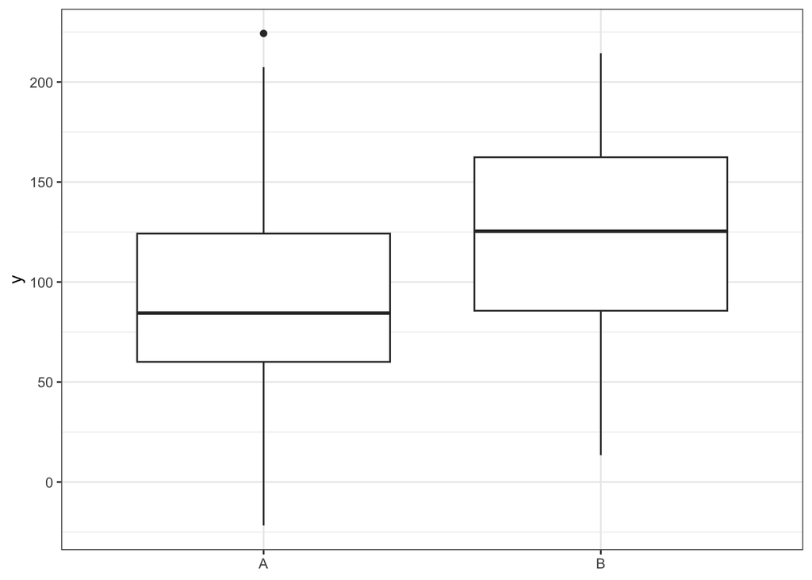

Two-goup simulated data.

We fit the model in brms:

```r
simple_lin_m0 <- brm(y~x, data=df1,

                     file = "models/simple_lin_m0.rds")
```

```
##             Estimate Est.Error     Q2.5     Q97.5
## b_Intercept 89.84760  7.200801 75.47945 104.28763
## b_xB        33.00253 10.433655 11.96027  53.69062
## sigma       51.31485  3.772500 44.65745  59.51646
```

- Intercept denotes $\alpha$, which in our case is the mean for group 1 (where x = 0)
- xB denotes $\beta$, which is the effect size, a.k.a. difference between means of group 1 and group 2.

The mean of group 2 is then $\alpha + \beta$ and the $\beta$ coefficient is our estimate for the difference between the groups.

You can do this by simply adding the posterior samples of the two coefficients.

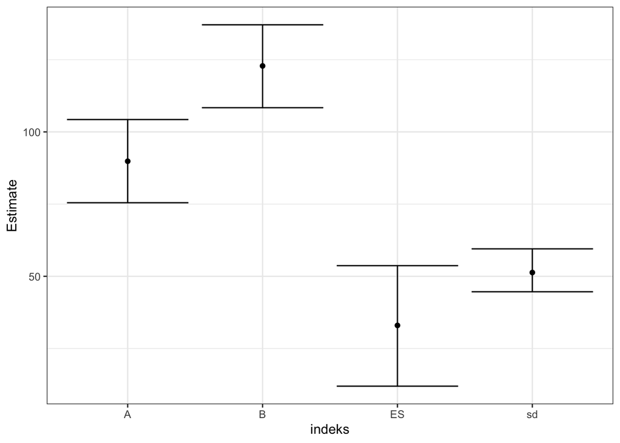

A plot of our estimates for the mean of each groups (A and B), the effect size, and the individual-level variation.

So far we used a categorical x-variable or predictor, sex, which we recoded as a continuos variable from which we have 2 values (0 and 1). We did this solely in the interest of the mathematics of line fitting. Thanks to this trick we could ask about the height of someone whose sex = 500. There is no problem getting an estimate the from the fitted model. All we have to do is to substitute the fitted values into intercept and slope coefficients. We will use the full posterior samples, so we do the calculation 4000 times (this is how many posterior samples we have) with slightly different estimates for intercept and slopes. As our Bayesian model considers all of these pairs plausible, our best option is to calcuate them all and plot the full posterior as an histogram. This posterior gives us the full information on uncertainty around the prediction.

```r
y_500 <- post$b_Intercept + post$b_xB * 500
```

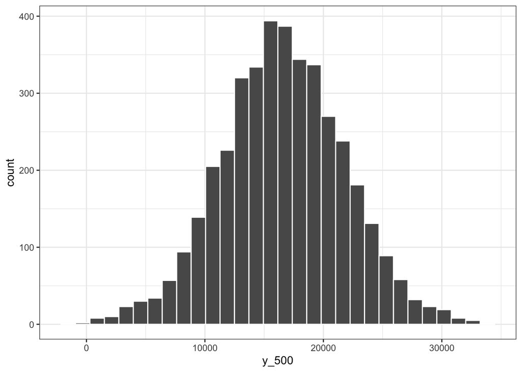

Posterior for an absurd prediction from linear model.

So the posterior depicted in the histogram tells us that the predicted height for a subject, whose sex = 500, is about 200-fold larger than the height of males and females. This is fine matemathically, but in the world it makes no sense in more than one level.

However, if our predictor really has more meaningful levels than 0 and 1, then this is exactly how we fit and interpret the linear regression. The meaning of Intercept and slope remains the same:

- The intercept is the estimated mean value (the expected value) of Y, if x = 0, or $E(Y\vert X=0)$.
- The slope gives the change in the expected value of Y, if we increase the X value by one unit.

As this is *linear* regression, it makes no difference, what the actual X value is, every one-unit change in X is accompanied with a slope-unit change in the predicted mean Y.

Now we simulate a regression for 2 continuous vars (N = 100, mean = 0, sd = 1):

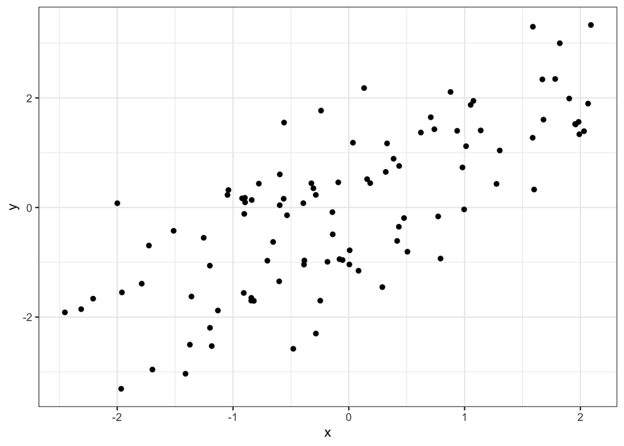

Simulated variables to test linear regression for continuous predictor.

We run the model and plot out 50 random fits, using 50 random draws from the posterior.

```r
simple_lin_m1 <- brm(y~x, data = xy_data,

                     prior = prior(normal(0, 1), class=b),


                     file = "models/simple_lin_m1.rds")
```

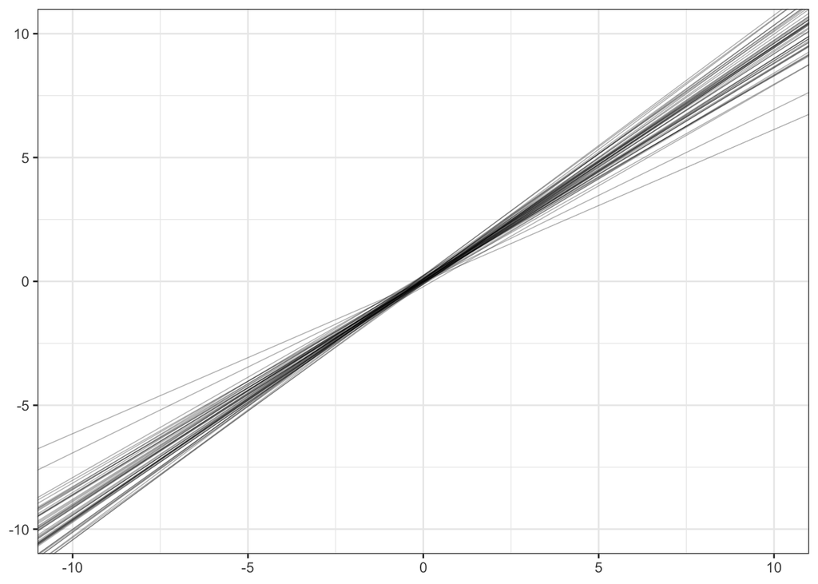

The model is fitted with data. We see 50 random predictions of best fit based on 50 random draws from the posterior.

```r
simple_lin_m1_post <- posterior_samples(simple_lin_m1) %>% sample_n(50)
ggplot(data =NULL) +
  geom_abline(aes(intercept= simple_lin_m1_post$b_Intercept,

                  slope = simple_lin_m1_post$b_x),

              size=0.3, alpha = 0.3)+

  xlim(-10, 10) + ylim(-10, 10)+ theme_bw()
```

All regression lines go through both mean(y) and mean(x) – both are 0 in our sim. The data range is about 3-4 units: see how the fit gradually becomes uncertain beyond that. Whether or not it makes sense to predict mean y values beyond the x data range is a scientific question – the relations in nature are rarely linear beyond a short range, if that. We are not doing linear regression because we think that the world is linear, we do it because it is convenient and the models are easy to interpret from coefficients alone. The surprising thing is, though, that it often works. This is the metaphysical mystery behind linear regression: it tends to work.

## Adding predictors

We add additional predictors when we believe (i) that all predictors ($x_1, ..., x_i$) influence the predicted variable (y), and (ii) that those influences are independent of each other. Independence leads to an additive process model.

$$y \sim normal(\mu, \sigma)$$

$$\mu = \alpha + \beta_1 x_1 + \beta_2 x_2 + ... + \beta_i x_i$$
and priors for $\alpha$, $\beta_1$, $\beta_2$, and $\sigma$.

What happens if we expand our regression model by including more predictors?

Now the slope of $x_1$ tells us, how much mean y changes, if we change $x_1$ by 1 unit and $x_2$ by 0 units (keep $x_2$ constant). Equivalently the slope of $x_2$ tells us, how much mean y changes, if we change $x_2$ by 1 unit and keep $x_1$ constant.

There is another way of interpreting multiple regression betas: $\beta_1$ tells us, what extra information on predicting the y value we get from $x_1$, if we already know how $x_2$ influences y. And conversely, what extra value in predicting y do we get from $x_2$, if we already know how $x_1$ influences y. For instance, we can predict someones height from the length of his right foot, but if we already know the prediction from the left foot, the right foot gives us (almost) nothing. And since including it in the model leaves very little covariation with height that is not also covariation of the left foot with height (and vice versa), then most of the predictive information that is included in the $R^2$, is not included in the respective betas (which consequently have extremely wide CI-s). This is collinearity.

some points:

- there is no reason to think that if we compare models $\mu = \alpha + \beta x_1$ and $\mu = \alpha + \beta_1 x_1 + \beta_2 x_2$, then $\beta$ and $\beta_1$ would be similar, or even have the same sign. The first is the total effect of $x_1$ on y, and the second is, in causal interpretation, the direct effect of $x_1$ on y.
- if you have several predictors in your regression, then for easier comparison of the betas, it makes sense to standardize them. Then the predictors that have betas farther from zero, have more effect on y.
- If you have only continuous predictors, use this `x_st = (x - mean(x))/sd(x)`. Then all your predictors have mean = 0 and sd = 1. Then the intercept is the value of y, when all predictors are at their mean values (which is always 0), and each slope gives the change in mean y, if the relevant predictor changes by one standard deviation, and all other predictors remain unchanged.
- If you have both continuous and binary predictors, then you will get approximate comparability of betas with the following transformation: `x_st2 = (x - mean(x))/(2*sd(x))`. Now the meaning of the slope changes - it is the change in mean y if x changes by 2 standard deviations (that is from the 2.5th quantile to the 97.5th quantile, which is a change that covers almost the range of x variation). As before, all other X-s are kept constant, and intercept is connected to mean values of all X-s.
- sometimes transforming a predictor helps to linearize the y vs x relationship.

The thing with adding predictors to linear regression process model, is that the additive model structure specifies parallel slopes. To see, what this means, lets simulate some data. We have a categorical variable z with 2 levels, “A” and “B”, denoting experimental conditions A and B. We have a x-variable (akin to a time variable), which covers the range 0 to 2 with 50 equally spaced points. And we have a continuous measurement variable y, which in experiment “A” goes up as x increases, and in experiment B goes down with equal rate.

```
## # A tibble: 6 × 3
##   z          x       y
##   <chr>  <dbl>   <dbl>
## 1 A     0      -0.145
## 2 A     0.0408  0.159
## 3 A     0.0816  0.0636
## 4 A     0.122   0.226
## 5 A     0.163  -0.113
## 6 A     0.204   0.130
```

What happens if we model these data by regression equation $y = \alpha + \beta_1 x + \beta_2 z$?

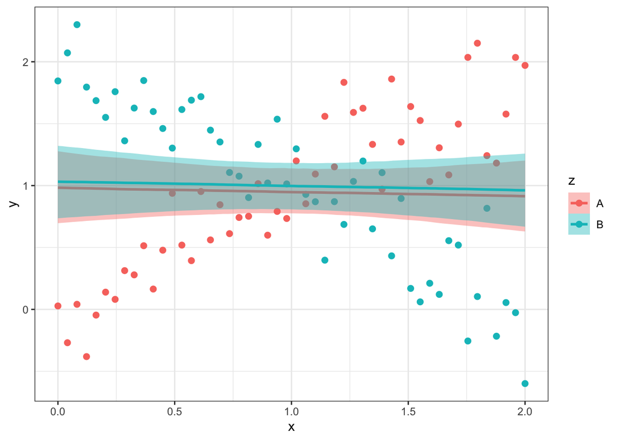

An additive model y = a + b1 * x + b2 * z, where z is a two-level categorical variable leads to fixed parallel slopes.

This model completely fails to capture the simulated data! The slopes of the A and B experiments are restricted to be parallel (fixed) by the additive model structure. The regression lines cross the $mean(y \vert x=A)$ and $mean(y \vert x=B)$ points, which in this simulation is the same value (1). This model fit loses in its predixtion the X-shaped data – the model thinks that A and B conditions lead to pretty much identical outcomes!

We can save the day by introducing an interaction term, which is actually a multiplication term. Like this $y = \alpha + \beta_1 x + \beta_2 z + \beta_3 x z$.

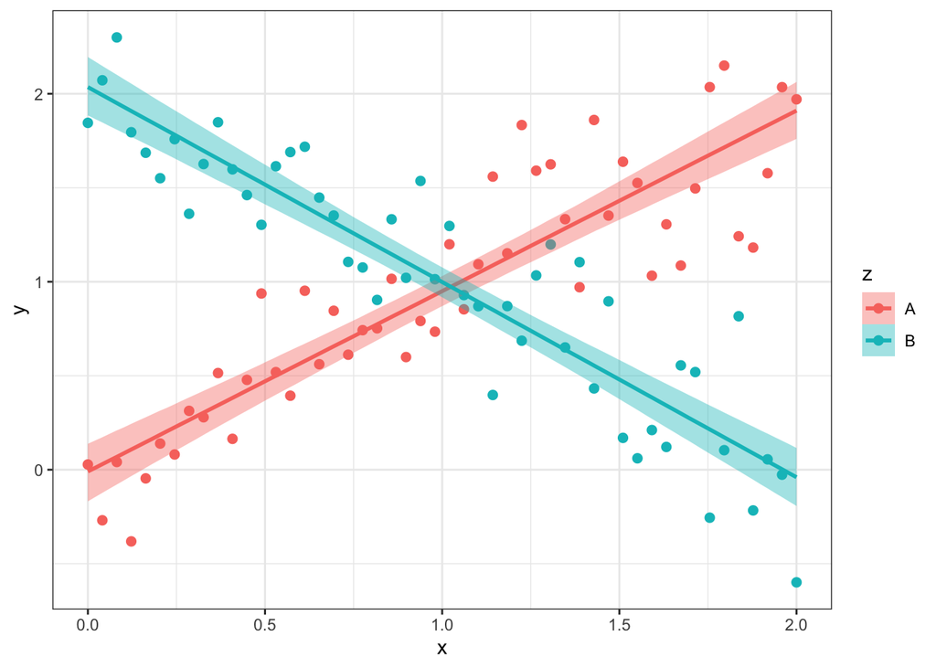

An interaction model y = a + b1 * x + b2 * z + b3 * x * z leads to free slopes.

Now the model fit perfectly recaptures the simulated data. Its general intercept = 0, its deflection for z=B is 2, its slope for x is 1, and its deflection for x=B is -2. So the fitted model is $y= 0 + 1x + 2z - 2xz$

these are the fitted model coefficients.

```r
posterior_summary(m_sim_interaction)[-6,]
```

```
##               Estimate  Est.Error       Q2.5      Q97.5
## b_Intercept -0.0110400 0.07945562 -0.1682108  0.1379032
## b_x          0.9610941 0.06813031  0.8323058  1.0946147
## b_zB         2.0473411 0.11085603  1.8273933  2.2652138
## b_x:zB      -1.9991338 0.09518095 -2.1831346 -1.8108486
## sigma        0.2908296 0.02123843  0.2525395  0.3349225
```

What happens if z is a continuous variable? The interaction model still works and gives a separate x slope for every z value, and conversely, it gives a seprate z slope for each x value. This means that the model expects that the relationship between x and y, e.g. how much a unit increase in x predicts the mean y value at this x value, to depend on the value of z. And vice versa, it symmetrically expects that the relationship between z and y, e.g. how much a unit increase in z predicts the mean y value at this z value, to depend on the value of x. The model neither knows nor cares, which variable, x or z, is of main interest to you, or which (if any) of them causally affects y. But it does know (assume) that the variablity of x is identical at all levels of z, and vice versa. Also, it provides no shrinkage.

It must be noted, though, that continuous interaction models require more data to accurately estimate the interaction term (the difference between slopes) than simple additive models.

What happens, when we omit the additive part of the model like this: $y= \alpha + \beta xz$?

Now the fitted intercept is at the mean values of $x \vert z=A$ and $x \vert z=B$, which in both cases is 1. The slopes are 0.2 and -0.3 for A and B, respectively.

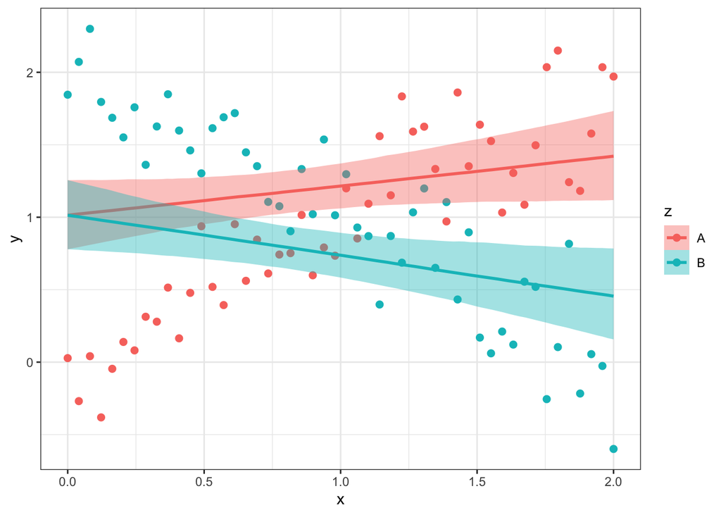

And an even simpler model $y = \beta xz$, where intercept = 0. Here the slopes are 1 and 0.5, for A and B, respectively.

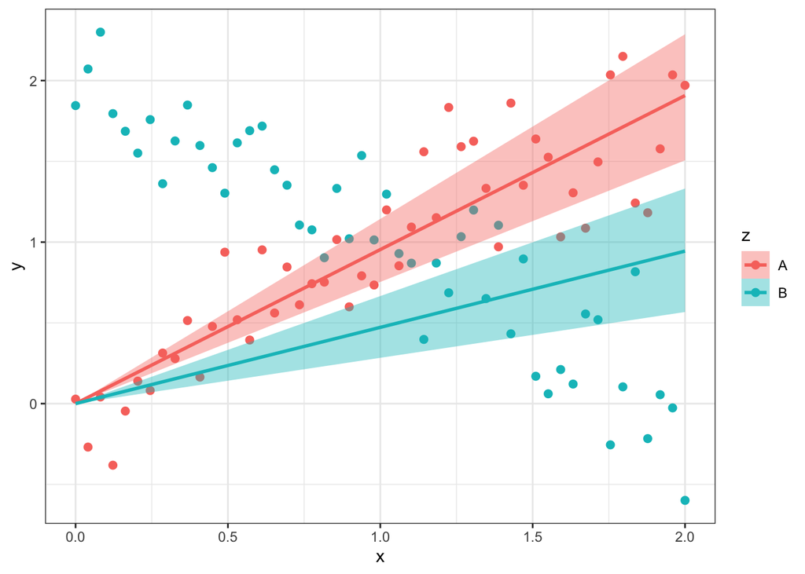

# 6. Generalized linear models

What to do, when the predicted variable (the y-variable) contains only two values (success/failure of a treatment, 0/1) and we want to model the probability of success or the success rate? Then we use the binomial likelihood and we have two major options for modelling. Firstly, we can use ordinary linear regression in the form

$$y_i \sim Binom(n, p)$$
$$p = \beta_0 + \beta_1 x_1$$
where y is the nunber of successes and n is the nr. of tries (defined as the nr. of failures plus the nr. of successes), or in brms code `brm(y|trials(n) ~ x1 + x2, famimiy= binomial(), link="Identity", ...)`. In this model the X-predictors are linearly associated with the probability of success and the coefficients are directly about probability of success. For example, $\beta_1$ tells us how much probability of success changes (in percentage points) if $X_1$ increases by one unit. In an randomized controlled experiment (RCT) with a binary outcome, the $\beta_1$ measures the difference in the probability of a positive outcome between treated and controls (coded in the $X_1$ variable): It is an absolute effect measure. This is all fine. However, there are two potential problems with linear models: (*i*) it is possible to predict probabilities that are outside the probability scale and, more importantly, (*ii*) it is often the case that binary y-variables are related to x-variables in a non-linear fashion with smaller increments in the probability of the outcome at extreme X-values. Therefore, a second modelling strategy was created where non-linearity of the response of the success probabilities to x-values is introduced by modelling log-odds, instead of modelling probabilities directly (see chapter 6.1). This strategy, called logistic regression, has been hugely popular for several decades, but recent work suggests that the simple linear approach is actually better for many approaches involving causal interpretation of the regression coefficients, especially in RCTs (Annu Rev Sociol 44, 1–16 2018). The reason is that slope coefficients for logistic regression (as well as for probit models, and for multinomial logistic regression) are downward biased due to unobserved variables that correlate with the success rate, but not necessarily with the X-variables. This means that logistic regression slopes cannot be causally interpreted by their magnitude (but can by sign or direction of the effects). Also, it is compliated to use them to campare nested models, or even effect sizes in RCTs. None of these problems apply for the linear models . The reader should keep this in mind when reading the rest of this chapter. If, however you should decide to fit a linear model instead of a logistic one, be sure to explain the reasons and give the Annual Review reference for the benefit of referees, who are very likely completely unaware of the problems with logistic regression and will (initially, hopefully) consider your decision a sign of gross incompetency.

y and n variables together make up the data that is used in constructing the predicted variable in the model.

but note that unobserved variables that do correlate with x-variables, are a problem for causal interpretation everywhere